# WordCloud Simple

Sergio Crespo 12/01/2017

Ya hemos visto como conseguir nuestras credenciales para conectarnos con la API de twitter. Ahora veremos como podemos sacar partido de los millones de tweets que se generan.

Un wordcloud puede ser una de las mejores herramientas para visualizar rápidamente la mayor parte de las palabras y los términos contenidos en los tweets. Tiene la ventaja de ser comprensible por la mayoría de los usuarios, siendo visualmente atractivo para los ojos humanos (si se hace de manera adecuada).

## ¿Cómo crear un wordcloud?

Los wordclouds son relativamente fáciles de hacer. Veamos los principales pasos de la receta:

##### PASO 1: Instanciamos librerías necesarias.

Estas son las librerías que necesitamos para las funciones que vamos a usar:

```r
library(ROAuth) # handshaking con API de Twitter
library(twitteR) # para poder descargar los tweets
library(tm) # librería de text mining
library(wordcloud) # con esta librería haremos el wordcloud
library(RColorBrewer) # para configurar colores del wordcloud
```

##### PASO 2: Declaramos las credenciales para la API de Twitter y creamos la conexión.

Aquí es donde declaramos las credenciales que hemos obtenido de la API de twitter.

```r
requestURL <- "https://api.twitter.com/oauth/request_token"
accessURL <- "https://api.twitter.com/oauth/access_token"
authURL <- "https://api.twitter.com/oauth/authorize"
consumerKey <- "6sUrs8DHMZ8kHf3r4lffL3XPk" # cliente de dev.twitter.com
consumerSecret <- "LHWoAvFMZTd76coIrvxPlzXky905Rh4DqItPRbAEWCdLrS3ed0" # clave secreta de dev.twitter.com
accessToken <- "3356887353-0sLpyiTbIos6bPTpmxRQGd0agSrUh5TUCjatnRU" # token de acceso
accessTokenSecret <- "stBUA32SKJNX4WskK1YmXs29rdBRe0qIDmkNrSKsiEw8O" # token de acceso secreto

setup_twitter_oauth(consumerKey, consumerSecret, accessToken, accessTokenSecret) #Autenticación
```

```
## [1] "Using direct authentication"
```

##### PASO 3: Descargamos los n tweets que contienen la palabra que buscamos.

```r
# descargamos 5000 tweets que contienen la palabra 'GHVip'
tweets <- searchTwitter('machine learning',  n=100, retryOnRateLimit=100)
# convierte los tweets a DataFrame
tweets <- twListToDF(tweets)
# obtiene el texto de los tweets
txt <- tweets$text
```

O podemos descargar los tweets de un usuario especifico:

```r
# descarga los tweets de @AlmeriaRUsers
user_tweets <- userTimeline("almeriarusers", 200)

# convierte los tweets a DataFrame
user_tweets <- twListToDF(user_tweets)

# obtiene el texto de los tweets
user_txt <- user_tweets$text
```

##### PASO 4: Limpieza de los datos.

```r
# elimina retweets
txtclean <- gsub("(RT|via)", "", user_txt)

# elimina menciones
txtclean <- gsub("@\\w+", "", txtclean)

# elimina simbolos de puntuación
txtclean <- gsub("[[:punct:]]", "", txtclean)

# elimina números
txtclean <- gsub("[[:digit:]]", "", txtclean)

# elimina links
txtclean <- gsub("http\\w+", "", txtclean)
```

##### PASO 5: Construimos el Corpus léxico y la matriz de términos.

Utilizamos la función **`Corpus`** para crear el corpus, y la función **`VectorSource`** para indicar que el texto está en el carácter vectorial **`txtclean`** . Con el fin de crear la matriz término-documento aplicamos la transformación diferentes, tales como números, signos de puntuación eliminación, minúsculas, etc.

```r
# construye un corpus
corpus <- Corpus(VectorSource(txtclean))

# Quitamos las palabras vacias de contenido en castellano (en, la, por,.) y la palabra que buscamos
corpus <- tm_map(corpus, removeWords, c(stopwords("spanish"),"machine learning"))

# elimina espacios en blanco extras
corpus <- tm_map(corpus, stripWhitespace)

# convierte a minúsculas
corpus <- tm_map(corpus, content_transformer(tolower))

# carga archivo de palabras vacías personalizada y lo convierte a ASCII
sw <- readLines("StopWords.txt",encoding="UTF-8")
sw <- iconv(sw, to="ASCII//TRANSLIT")

# elimina palabras vacías personalizada
corpus = tm_map(corpus, removeWords, sw)

# crea una matriz de términos
tdm <- TermDocumentMatrix(corpus)

# convierte a una matriz
m = as.matrix(tdm)
```

##### PASO 6: Obtenemos las frecuencias de las ocurrencias de palabras.

```r
# conteo de palabras en orden decreciente
wf <- sort(rowSums(m),decreasing=TRUE)

# crea un data frame con las palabras y sus frecuencias
dm <- data.frame(word = names(wf), freq=wf)
```

##### PASO 7: Dibujamos el WordCloud

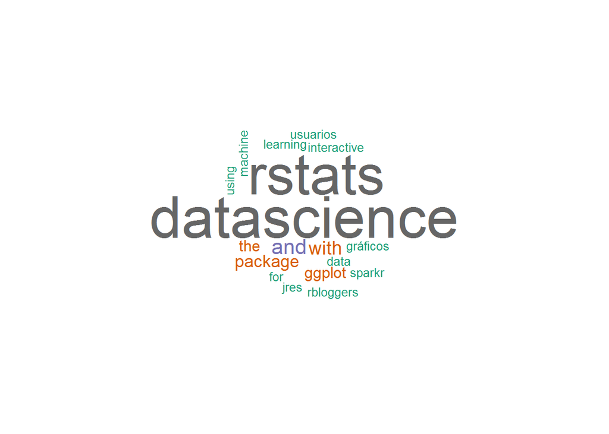

```r
# grafica en nube de palabras
wordcloud(dm$word, dm$freq, random.order=FALSE, colors=brewer.pal(8, "Dark2"))
```